# R u Ready? HS2025 | Psychologie der Digitalisierung - Einheit 12

Sandra Grinschgl, Aaron Friedli, Lars Schilling

## R u Ready? Reproduzierbare Datenaufbereitung und -analyse mit R

HS 2025  
**LV-Leitung**: Dr. Sandra Grinschgl / MSc. Aaron Friedli  
**Tutor**: BSc. Lars Schilling  
**12. Einheit**, 03.12.2025

## Heute:

[interactive chart not shown]

## Fragen zur R Hausübung 2??

## Abgabe simulierte Datensätze

Auf ILIAS findet ihr Ordner mit eurem Namen. Diese sind nach dem PsychDS System strukturiert. In Raw findet ihr dann eure individuellen Datensätze

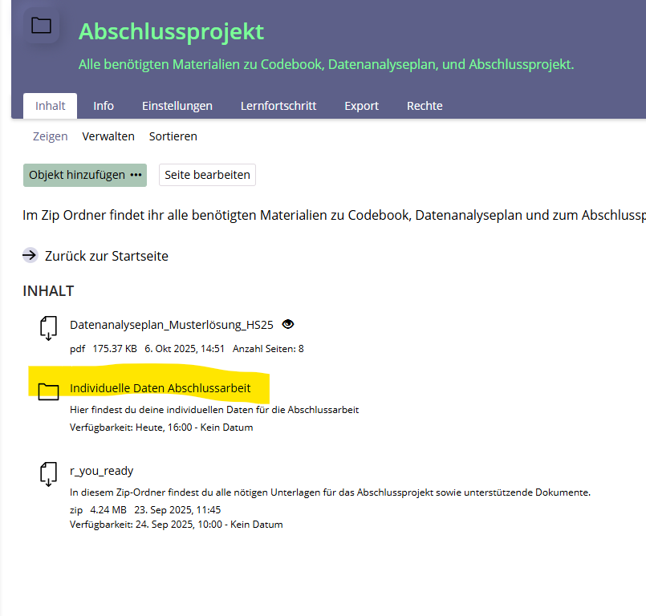

## Abschlussarbeit / Leistungsnachweis

[interactive chart not shown]

## **Simulierte Datensätze**

- Vorgehen: Eine Funktion simuliert Population(en) und zieht daraus zufällig Datenpunkte. Diese Zufälligkeit der Ziehung führt dazu, dass sich eure **Datensätze** **unterscheiden**!
- Dadurch ergeben sich Unterschiede in den **Hypothesentests und deskriptiven Statistiken**.
- Aber: Die Ergebnisse werden sich dennoch in einer vergleichbaren Range voneinander bewegen.

## **Plausible Ergebnisse**

- Angenommen der Effekt der Intervention hat wirklich **keine Auswirkung** auf das Offloading Verhalten der Personen (H0 ist wahr).
  - ✅**H0** = Keine Gruppenunterschiede zwischen above und below gruppen.
  - ❌**H1** = Gruppen unterscheiden sich voneinander im Offlading Verhalten.
- Hypothesentest: t-Test für unabhängige Stichproben (`above` vs. `below)`
- Wie hoch ist die Wahrscheinlichkeit das wir trotzdem ein sigifikantes Ergebnis (Fehler 1. Art) erhalten?

## t-Tests

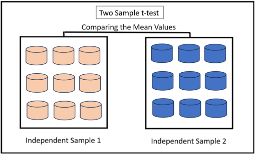

Mittelwertvergleiche

- Für unabhängige Stichproben: Testet, ob sich die Mittelwerte zweier unabhängiger Gruppen unterscheiden.
- Für abhängige Stichproben: Testet, ob sich die Mittelwerte derselben Personen in zwei Bedingungen (z. B. Messwiederholung) unterscheiden.
- Voraussetzungen: Normalverteilung, Varianzhomogenität
- Alternative: z. B. Welch-t-Test

## t-Test: Voraussetzungsprüfung

**Levene-Test**

Der Levene Test überprüft Varianzhomogenität! Varianzhomogenität bedeutet, dass alle Gruppen in einer Analyse ungeführ die gleiche Streuung aufweisen, bzw. ähnlich um ihren Mittelwert schwanken.

```r
dat_full_below_above <- dat_full |>
  filter(group_all != "control")

dat_full_below_above$group_all <- as.factor(dat_full_below_above$group_all)
```

```r
library(car)

leveneTest(dat_full_below_above$pre4, dat_full_below_above$group_all)
```

```
Levene's Test for Homogeneity of Variance (center = median)
       Df F value Pr(>F)
group   1  2.8442 0.0947 .
      104
---
Signif. codes:  0 '***' 0.001 '**' 0.01 '*' 0.05 '.' 0.1 ' ' 1
```

## t-Test: Beispiel

```r
t.test(pre4 ~ group_all, data = dat_full_below_above, var.equal = TRUE)
```

```
    Two Sample t-test

data:  pre4 by group_all
t = 7.9845, df = 104, p-value = 0.000000000001991
alternative hypothesis: true difference in means between group above and group below is not equal to 0
95 percent confidence interval:
 20.25170 33.63509
sample estimates:
mean in group above mean in group below
           59.66038            32.71698
```

```r
effsize::cohen.d(pre4 ~ group_all, data = dat_full_below_above)
```

```
Cohen's d

d estimate: 1.551045 (large)
95 percent confidence interval:
   lower    upper
1.111706 1.990383
```

## **Grundlegende t-Test-Funktionen**

| **Funktion** | **Beschreibung** |
| --- | --- |
| `t.test` | Allgemeine Funktion für verschiedene t-Tests: Ein-Stichproben-, unabhängige und abhängige Stichproben. |
| `t.test(av, mu = x)` | Ein-Stichproben-t-Test. *av* = abhängige Variable, *x* = Vergleichswert der Population. |
| `t.test(av ~ uv)` | Welch-t-Test für unabhängige Stichproben. *av* = abhängige Variable, *uv* = Gruppenvariable (Ungleiche Varianzen erlaubt). |
| `t.test(av ~ uv, var.equal = TRUE)` | Klassischer t-Test für unabhängige Stichproben (Varianzgleichheit vorausgesetzt). |

## **Paired t-Test, Varianzhomogenität und Effektgrössen**

| **Funktion** | **Beschreibung** |
| --- | --- |
| `t.test(av1, av2, paired = TRUE)` | t-Test für abhängige Stichproben (z. B. Prä–Post). *av1* und *av2* = Messzeitpunkte. |
| `leveneTest(av, uv)` * | Levene-Test auf Varianzhomogenität für unabhängige Gruppen. Aus dem **car**-Paket. |
| `effsize::cohen.d()` * | Berechnet Cohen’s d + Konfidenzintervall. Aus dem **efffsize**-Paket. |

## **Heute haben wir…**

… uns die simulierten Datensätze für die Abschlussarbeit angeschaut.

## Hausübung

R Übung 3 bis 12.12.25

**Nächste Woche:** Aaron übernimmt beide Gruppen

[figure not shown]

with ChatGPT